# Steps 5–6: Where to Find the Best Chinese, Vietnamese, and Japanese Food in New Orleans

- Show All Code
- Hide All Code
- View Source

Establishing the city boundary and choosing a geographic system

Author

Samuel Lin

Published

November 11, 2026

```r
library(tidyverse)
library(sf)
library(tigris)
library(scales)
library(viridis)
library(knitr)

options(tigris_use_cache = TRUE)
crs_proj <- 26915   # UTM zone 15N (meters): accurate areas and joins for New Orleans

dir.create("figures", showWarnings = FALSE)
dir.create("tables", showWarnings = FALSE)
dir.create("data/boundaries", recursive = TRUE, showWarnings = FALSE)
theme_set(theme_minimal(base_size = 12))

save_fig <- function(plot, name, width = 8, height = 6) {
  ggsave(file.path("figures", name), plot, width = width, height = height, dpi = 200, bg = "white")
  plot
}
fmt <- function(x, digits = 2) formatC(x, format = "f", digits = digits)
```

## Starting point (from Steps 1–4)

**Research question:** *Where can someone find the best Chinese, Vietnamese, and Japanese food in New Orleans, and which part of the city is best for finding it?*

New Orleans is known for Creole and Cajun cooking, but it also has a large East Asian and Southeast Asian food scene, including one of the largest Vietnamese communities in the United States. The three cuisines belong together because they are the three largest Asian restaurant categories in the city, they compete for the same “let’s get Asian food” decision, and some restaurants are tagged with more than one of them.

```r
business <- readRDS(business_rds)
business$attributes <- NULL   # nested columns not needed here
business$hours <- NULL
business <- as_tibble(business)
if (!"is_open" %in% names(business)) business$is_open <- 1L

nola <- business |>
  filter(state == "LA",
         str_to_title(str_squish(city)) == "New Orleans",
         !is.na(categories),
         str_detect(categories, regex("Restaurants", ignore_case = TRUE))) |>
  mutate(business_name = str_squish(name),
         postal_code   = str_sub(na_if(postal_code, ""), 1, 5)) |>
  distinct(business_id, .keep_all = TRUE)

cat_long <- nola |>
  select(business_id, categories) |>
  separate_rows(categories, sep = ",") |>
  mutate(category = str_to_lower(str_squish(categories))) |>
  filter(category != "") |>
  distinct(business_id, category)

# One row per restaurant-cuisine pair (a restaurant tagged two cuisines appears twice)
cuisine_long <- cat_long |>
  filter(category %in% cuisines) |>
  transmute(business_id, cuisine = str_to_title(category))

selected <- nola |>
  inner_join(
    cuisine_long |>
      group_by(business_id) |>
      summarise(n_cuisines = n(),
                cuisine_list = paste(sort(cuisine), collapse = " + "), .groups = "drop"),
    by = "business_id"
  ) |>
  mutate(cuisine = if_else(n_cuisines > 1, "Mixed", cuisine_list))

tibble(
  Measure = c("New Orleans restaurants (Yelp city label)", "Chinese, Vietnamese, or Japanese",
              "…still open in the Yelp snapshot", "…tagged with two of the cuisines", "Different ZIP codes"),
  Value = c(nrow(nola), nrow(selected), sum(selected$is_open == 1),
            sum(selected$n_cuisines > 1), n_distinct(selected$postal_code, na.rm = TRUE))
) |> kable(format.args = list(big.mark = ","), caption = "The restaurant group")
```

The restaurant group

| Measure | Value |
| --- | --- |
| New Orleans restaurants (Yelp city label) | 2,259 |
| Chinese, Vietnamese, or Japanese | 168 |
| …still open in the Yelp snapshot | 122 |
| …tagged with two of the cuisines | 12 |
| Different ZIP codes | 22 |

```r
selected |>
  count(`Cuisine label` = cuisine_list, name = "Restaurants", sort = TRUE) |>
  kable(caption = "How restaurants are tagged (restaurants with two cuisines are labeled 'Mixed' on maps)")
```

How restaurants are tagged (restaurants with two cuisines are labeled ‘Mixed’ on maps)

| Cuisine label | Restaurants |
| --- | --- |
| Chinese | 58 |
| Japanese | 51 |
| Vietnamese | 47 |
| Chinese + Vietnamese | 9 |
| Chinese + Japanese | 2 |
| Japanese + Vietnamese | 1 |

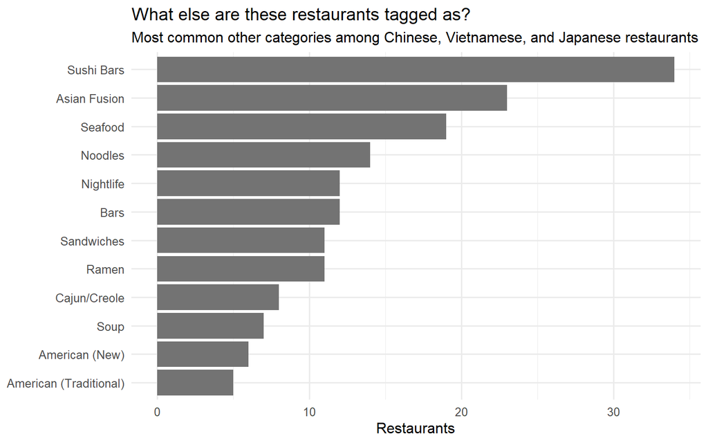

```r
cooccur <- cat_long |>
  semi_join(selected, by = "business_id") |>
  filter(!category %in% c("restaurants", "food", cuisines)) |>
  count(category, sort = TRUE) |>
  slice_head(n = 12) |>
  mutate(category = fct_reorder(str_to_title(category), n))

cooccur_chart <- ggplot(cooccur, aes(n, category)) +
  geom_col(fill = "grey45") +
  labs(title = "What else are these restaurants tagged as?",
       subtitle = "Most common other categories among Chinese, Vietnamese, and Japanese restaurants",
       x = "Restaurants", y = NULL)

save_fig(cooccur_chart, "category_cooccurrence.png", height = 5)
```

## Step 5: Establish the official New Orleans boundary

Yelp’s `city` field is typed text from each business’s mailing address. A **spatial join** provides an independent check: each restaurant’s latitude/longitude point is matched to the U.S. Census place polygon that contains it (`st_within`).

```r
la_places <- tigris::places(state = "LA", cb = TRUE, year = 2024, class = "sf") |>
  st_transform(crs_proj) |>
  st_make_valid()

nola_boundary <- la_places |> filter(NAME == "New Orleans")

restaurant_points <- nola |>
  filter(!is.na(latitude), !is.na(longitude)) |>
  st_as_sf(coords = c("longitude", "latitude"), crs = 4326, remove = FALSE) |>
  st_transform(crs_proj) |>
  st_join(la_places |> select(place_name = NAME), join = st_within, left = TRUE) |>
  distinct(business_id, .keep_all = TRUE) |>
  mutate(place_name  = replace_na(place_name, "Outside any Census place"),
         inside_city = place_name == "New Orleans")

restaurant_points |>
  st_drop_geometry() |>
  count(`Census place` = place_name, name = "Restaurants", sort = TRUE) |>
  kable(caption = "All restaurants Yelp labels 'New Orleans': which Census place are they actually in?")
```

All restaurants Yelp labels ‘New Orleans’: which Census place are they actually in?

| Census place | Restaurants |
| --- | --- |
| New Orleans | 2202 |
| Elmwood | 18 |
| Jefferson | 13 |
| Harahan | 10 |
| Terrytown | 4 |
| Metairie | 3 |
| River Ridge | 3 |
| Arabi | 2 |
| Harvey | 2 |
| Gretna | 1 |
| Kenner | 1 |

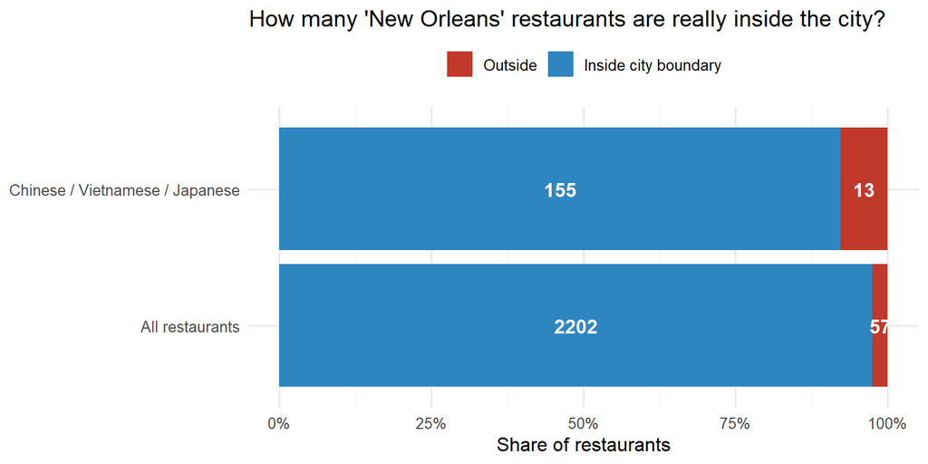

```r
asian_points <- restaurant_points |>
  inner_join(select(selected, business_id, cuisine, cuisine_list), by = "business_id")

inside_chart <- bind_rows(
  st_drop_geometry(restaurant_points) |> mutate(group = "All restaurants"),
  st_drop_geometry(asian_points) |> mutate(group = "Chinese / Vietnamese / Japanese")
) |>
  count(group, inside_city) |>
  group_by(group) |>
  mutate(share = n / sum(n)) |>
  ggplot(aes(share, group, fill = inside_city)) +
  geom_col() +
  geom_text(aes(label = n), position = position_stack(vjust = 0.5), color = "white", fontface = "bold") +
  scale_x_continuous(labels = percent) +
  scale_fill_manual(values = c(`TRUE` = "#2E86C1", `FALSE` = "#C0392B"),
                    labels = c(`TRUE` = "Inside city boundary", `FALSE` = "Outside")) +
  labs(title = "How many 'New Orleans' restaurants are really inside the city?",
       x = "Share of restaurants", y = NULL, fill = NULL) +
  theme(legend.position = "top")

save_fig(inside_chart, "step5_inside_outside.png", height = 4)
```

```r
outside_tbl <- asian_points |>
  st_drop_geometry() |>
  filter(!inside_city) |>
  select(Restaurant = business_name, Cuisine = cuisine_list, Address = address,
         ZIP = postal_code, `Census place` = place_name, Stars = stars, Reviews = review_count)

if (nrow(outside_tbl) == 0) {
  cat("All selected restaurants are inside the New Orleans boundary.")
} else {
  kable(outside_tbl, caption = "Selected restaurants labeled 'New Orleans' but located outside the city")
}
```

Selected restaurants labeled ‘New Orleans’ but located outside the city

| Restaurant | Cuisine | Address | ZIP | Census place | Stars | Reviews |
| --- | --- | --- | --- | --- | --- | --- |
| Sake Cafe of Elmwood | Japanese | 1130 S Clearview Pkwy | 70123 | Elmwood | 3.0 | 110 |
| Hong Kong Kitchen | Chinese | 1820 Dickory Ave | 70123 | Harahan | 4.5 | 97 |
| Dejepe Bakery | Vietnamese | 775 Berhman Hwy | 70056 | Terrytown | 4.5 | 24 |
| Jade Buddha Chinese Restaurant | Chinese | 4433 Jefferson Hwy | 70121 | Jefferson | 3.0 | 29 |
| Grand Buffet | Chinese | 800 S Clearview Pkwy | 70123 | Elmwood | 3.0 | 41 |
| Oriental Triangle Chinese | Chinese | 4808 Jefferson Hwy | 70121 | Elmwood | 3.0 | 50 |
| China Kitchen | Chinese | 700 Terry Pkwy, Ste A | 70056 | Terrytown | 4.0 | 37 |
| Kim Anh’s Noodle House | Vietnamese | 6624 Jefferson Hwy | 70123 | Harahan | 4.0 | 115 |
| Lotus Vietnamese Cuisine | Vietnamese | 5359 Mounes St, Ste H | 70123 | Elmwood | 3.5 | 11 |
| Kyoto 2 | Japanese | 5608 Citrus Blvd | 70123 | Elmwood | 4.0 | 106 |
| Chun Lee Chinese Restaurant | Chinese | 1100 Elmwood Park Blvd | 70123 | Elmwood | 3.0 | 16 |
| China Palace | Chinese | 1915 Hickory Ave | 70123 | Harahan | 4.5 | 23 |
| Chinese American Cafe | Chinese | 1228 Jefferson Hwy | 70121 | Jefferson | 3.5 | 34 |

```r
asian_points |>
  st_drop_geometry() |>
  count(inside_city, cuisine) |>
  pivot_wider(names_from = inside_city, values_from = n, values_fill = 0) |>
  rename(Cuisine = cuisine, any_of(c(Inside = "TRUE", Outside = "FALSE"))) |>
  kable(caption = "Inside vs. outside the city, by cuisine")
```

Inside vs. outside the city, by cuisine

| Cuisine | Outside | Inside |
| --- | --- | --- |
| Chinese | 8 | 50 |
| Japanese | 2 | 49 |
| Vietnamese | 3 | 44 |
| Mixed | 0 | 12 |

**What the mismatches mean:** the U.S. Postal Service, not city limits, decides the city name on a mailing address. Businesses in parts of Jefferson Parish (such as Metairie and Harahan, ZIP codes 70121 and 70123) receive “New Orleans” addresses even though they are outside the city. These restaurants are **excluded** from the analysis, because the question is about New Orleans and they would fall outside every city-based boundary in Step 6.

```r
analysis_points <- asian_points |> filter(inside_city)
```

The analysis set is **155** restaurants inside the city boundary (down from 168).

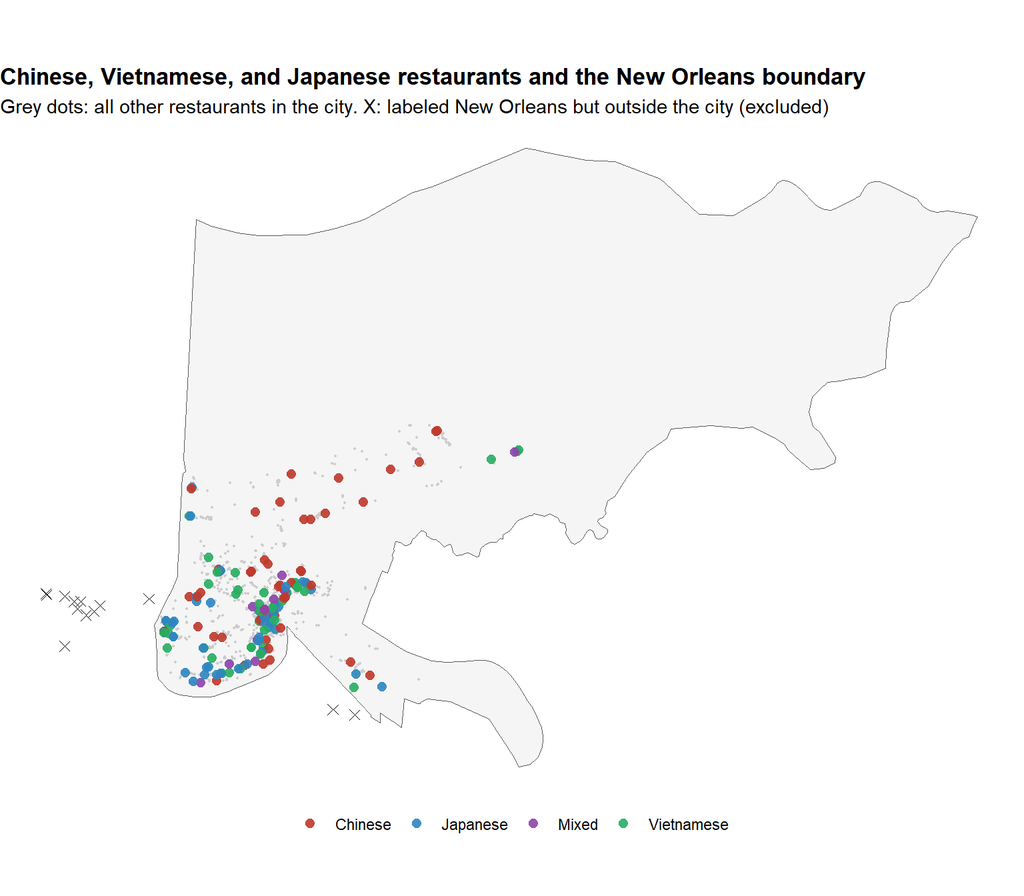

```r
boundary_map <- ggplot() +
  geom_sf(data = nola_boundary, fill = "grey96", color = "grey35") +
  geom_sf(data = filter(restaurant_points, inside_city), color = "grey80", size = 0.4) +
  geom_sf(data = filter(asian_points, !inside_city), shape = 4, color = "black", size = 2.5) +
  geom_sf(data = analysis_points, aes(color = cuisine), size = 2.2, alpha = 0.9) +
  scale_color_manual(values = cuisine_colors) +
  labs(title = "Chinese, Vietnamese, and Japanese restaurants and the New Orleans boundary",
       subtitle = "Grey dots: all other restaurants in the city. X: labeled New Orleans but outside the city (excluded)",
       color = NULL) +
  theme_void() +
  theme(plot.title = element_text(face = "bold"), legend.position = "bottom")

save_fig(boundary_map, "new_orleans_boundary_map.png", height = 7)
```

## Step 6: Choose and defend a geographic system

Someone deciding where to eat thinks in terms of *parts of town*: “Is it worth driving out to the East for pho, or should we stay downtown?” The geographic system should therefore divide the city into areas that (1) a general reader recognizes and (2) each contain enough restaurants to compare. Three systems are tested:

- **ZIP Code Tabulation Areas (ZCTAs):** Census versions of ZIP codes, clipped to the city boundary.
- **Census tracts:** small statistical areas designed for population data.
- **Neighborhood Statistical Areas (NSAs):** the City of New Orleans’ official neighborhoods (Data.NOLA.gov).

```r
clip_to_city <- function(b) {
  b <- b |> st_transform(crs_proj) |> st_make_valid()
  b <- suppressWarnings(st_intersection(b, st_geometry(nola_boundary)))
  b <- suppressWarnings(st_collection_extract(b, "POLYGON"))
  b <- b |> group_by(area_name) |> summarise(.groups = "drop")
  b$area_km2 <- as.numeric(st_area(b)) / 1e6
  filter(b, area_km2 > 0.25)   # drop slivers along the city edge
}

pick_col <- function(df, candidates) {
  hit <- intersect(candidates, names(df))
  if (length(hit) == 0) stop("None of these columns found: ", paste(candidates, collapse = ", "))
  hit[1]
}

# ZCTAs (New Orleans ZIPs start with 701)
zcta_raw <- tigris::zctas(year = 2020, cb = TRUE, starts_with = "701", class = "sf")
zcta_areas <- zcta_raw |>
  transmute(area_name = .data[[pick_col(zcta_raw, c("ZCTA5CE20", "GEOID20", "ZCTA5CE10", "GEOID"))]]) |>
  clip_to_city()

# Census tracts (Orleans Parish = City of New Orleans)
tract_raw <- tigris::tracts(state = "LA", county = "Orleans", year = 2024, cb = TRUE, class = "sf")
tract_areas <- tract_raw |>
  transmute(area_name = .data[[pick_col(tract_raw, c("NAMELSAD", "NAME", "GEOID"))]]) |>
  clip_to_city()

# Neighborhood Statistical Areas: downloaded once, then read from disk
nsa_file <- "data/boundaries/neighborhood_statistical_areas.geojson"
nsa_urls <- c(
  "https://maps.nola.gov/server/rest/services/Reference/Reference_Layers/MapServer/0/query?where=1%3D1&outFields=*&outSR=4326&f=geojson",
  "https://data.nola.gov/api/v3/views/exvn-jeh2/query.geojson?accessType=DOWNLOAD",
  "https://data.nola.gov/api/geospatial/exvn-jeh2?method=export&format=GeoJSON"
)
read_nsa <- function(path) { x <- st_read(path, quiet = TRUE); if (nrow(x) < 10) stop("bad file"); x }

nsa_raw <- if (file.exists(nsa_file)) tryCatch(read_nsa(nsa_file), error = \(e) NULL) else NULL
for (u in nsa_urls) {
  if (!is.null(nsa_raw)) break
  nsa_raw <- tryCatch({ download.file(u, nsa_file, mode = "wb", quiet = TRUE); read_nsa(nsa_file) },
                      error = \(e) NULL)
}

nsa_ok <- !is.null(nsa_raw)
if (nsa_ok) {
  nsa_areas <- nsa_raw |>
    transmute(area_name = str_to_title(.data[[pick_col(nsa_raw, c("GNOCDC_LAB", "gnocdc_lab", "LUP_LAB",
                                                                   "lup_lab", "NAME", "name"))]])) |>
    clip_to_city()
}

geo_systems <- list(`ZIP/ZCTA` = zcta_areas, `Census tract` = tract_areas)
if (nsa_ok) geo_systems[["Neighborhood Statistical Area"]] <- nsa_areas
```

### Spatial joins and comparison table

```r
assignments <- imap(geo_systems, \(areas, sys) {
  analysis_points |>
    st_join(select(areas, area_name), join = st_within, left = TRUE) |>
    distinct(business_id, .keep_all = TRUE) |>
    st_drop_geometry() |>
    mutate(system = sys)
})

area_counts <- imap(geo_systems, \(areas, sys) {
  areas |>
    st_drop_geometry() |>
    select(area_name) |>
    left_join(count(filter(assignments[[sys]], !is.na(area_name)), area_name, name = "restaurants"),
              by = "area_name") |>
    mutate(restaurants = replace_na(restaurants, 0L), system = sys)
}) |> bind_rows()

comparison <- area_counts |>
  group_by(`Geographic system` = system) |>
  summarise(
    `Number of areas`           = n(),
    `Areas with 1+ restaurants` = sum(restaurants >= 1),
    `Areas with 3+ restaurants` = sum(restaurants >= min_area_restaurants),
    `Smallest area count (non-empty)` = min(restaurants[restaurants > 0]),
    `Median per area`           = median(restaurants),
    `Largest area count`        = max(restaurants),
    `Share in comparable areas` = sum(restaurants[restaurants >= min_area_restaurants]) / nrow(analysis_points),
    .groups = "drop"
  ) |>
  left_join(
    bind_rows(assignments) |>
      group_by(`Geographic system` = system) |>
      summarise(`Restaurants assigned` = sum(!is.na(area_name)),
                `Unmatched restaurants` = sum(is.na(area_name)), .groups = "drop"),
    by = "Geographic system"
  ) |>
  relocate(`Restaurants assigned`, `Unmatched restaurants`, .after = `Number of areas`)

write_csv(comparison, "tables/geography_comparison.csv")
comparison |>
  mutate(`Share in comparable areas` = percent(`Share in comparable areas`, accuracy = 1)) |>
  kable(caption = "Comparison of geographic systems (restaurants inside New Orleans)")
```

Comparison of geographic systems (restaurants inside New Orleans)

| Geographic system | Number of areas | Restaurants assigned | Unmatched restaurants | Areas with 1+ restaurants | Areas with 3+ restaurants | Smallest area count (non-empty) | Median per area | Largest area count | Share in comparable areas |
| --- | --- | --- | --- | --- | --- | --- | --- | --- | --- |
| Census tract | 181 | 155 | 0 | 66 | 17 | 1 | 0 | 24 | 59% |
| Neighborhood Statistical Area | 70 | 155 | 0 | 42 | 18 | 1 | 1 | 24 | 79% |
| ZIP/ZCTA | 18 | 154 | 1 | 17 | 13 | 2 | 4 | 31 | 94% |

The last column is the share of restaurants that sit in an area with at least 3 restaurants, where an area average means something.

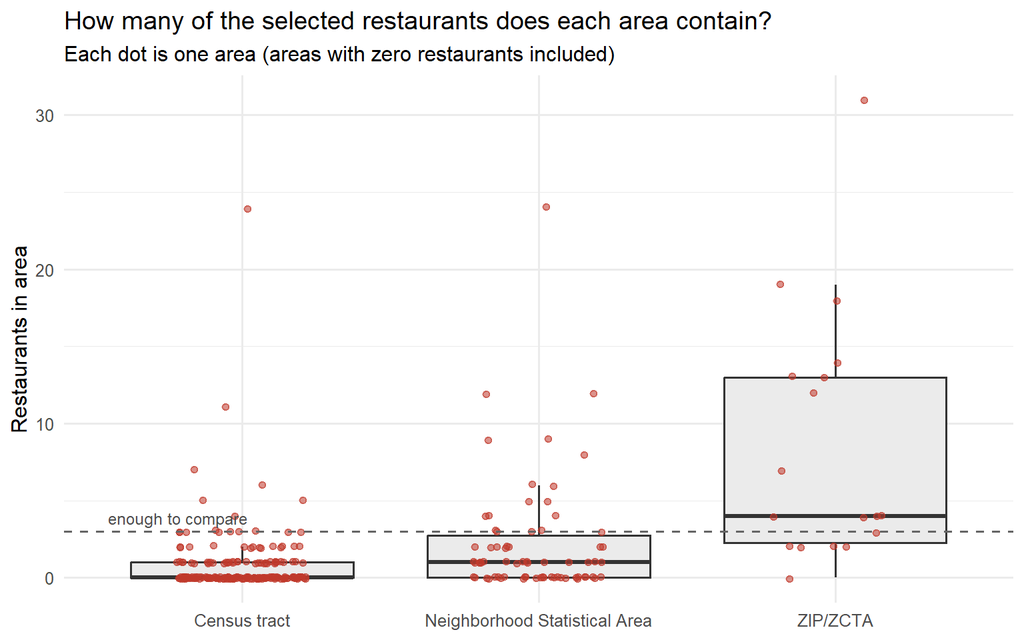

```r
geo_compare_chart <- area_counts |>
  ggplot(aes(system, restaurants)) +
  geom_boxplot(outlier.shape = NA, fill = "grey92") +
  geom_jitter(width = 0.22, height = 0.08, alpha = 0.55, color = "#C0392B") +
  geom_hline(yintercept = min_area_restaurants, linetype = "dashed", color = "grey40") +
  annotate("text", x = 0.55, y = min_area_restaurants, label = "enough to compare",
           hjust = 0, vjust = -0.6, size = 3.2, color = "grey30") +
  labs(title = "How many of the selected restaurants does each area contain?",
       subtitle = "Each dot is one area (areas with zero restaurants included)",
       x = NULL, y = "Restaurants in area")

save_fig(geo_compare_chart, "geography_comparison.png", height = 5)
```

### Maps of each system

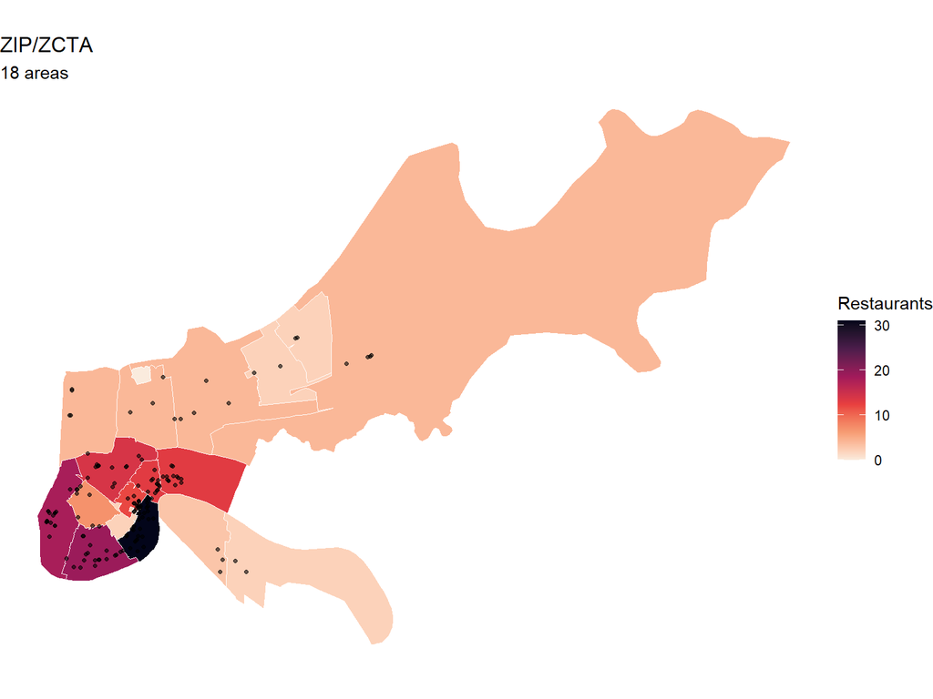

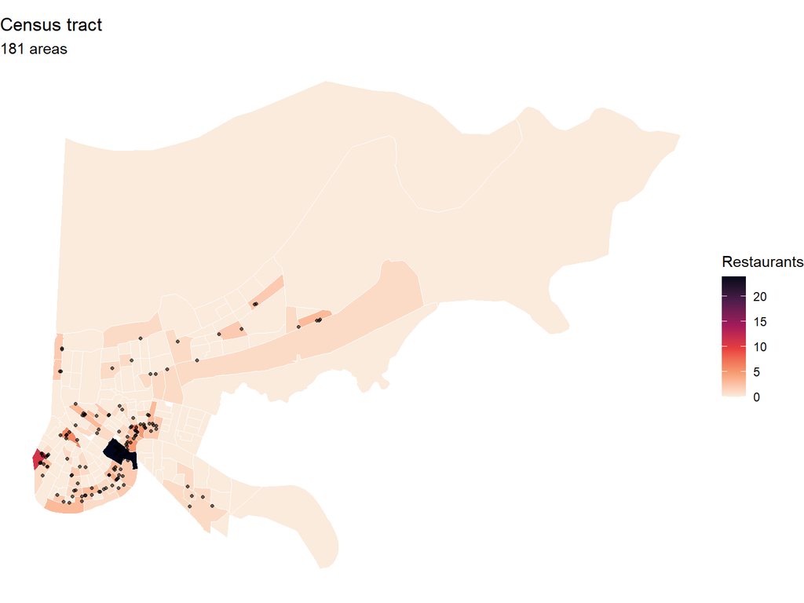

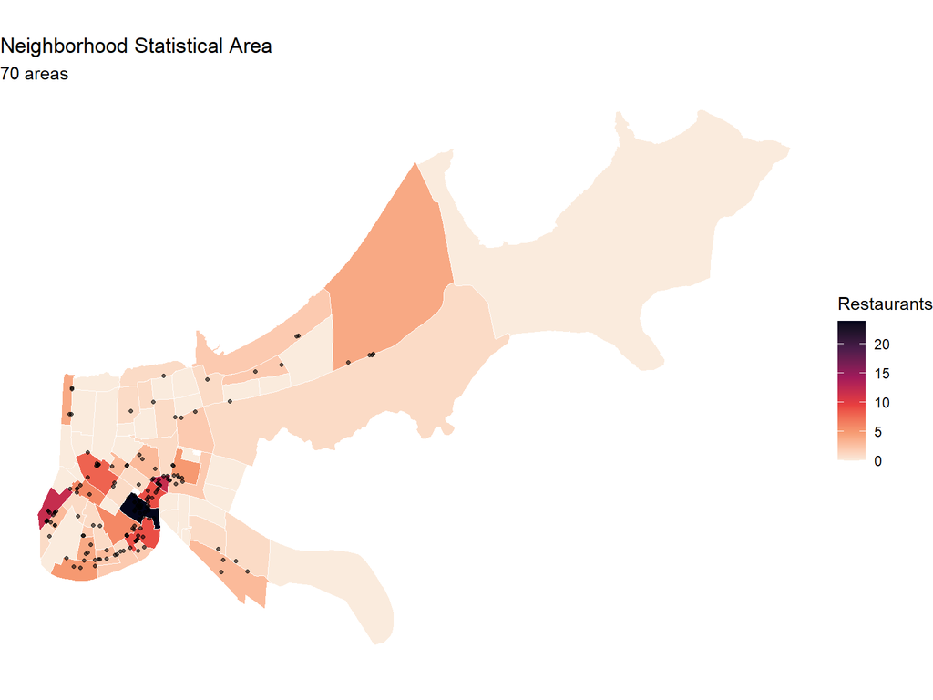

```r
system_maps <- imap(geo_systems, \(areas, sys) {
  p <- areas |>
    left_join(filter(area_counts, system == sys) |> select(area_name, restaurants), by = "area_name") |>
    ggplot() +
    geom_sf(aes(fill = restaurants), color = "white", linewidth = 0.2) +
    geom_sf(data = analysis_points, size = 0.9, color = "black", alpha = 0.6) +
    scale_fill_viridis_c(option = "rocket", direction = -1, name = "Restaurants") +
    labs(title = sys, subtitle = paste(nrow(areas), "areas")) +
    theme_void()
  save_fig(p, paste0("map_", str_replace_all(str_to_lower(sys), "[^a-z]+", "_"), ".png"), height = 6)
})
walk(system_maps, print)
```

### Ratings by area in each system

```r
area_ratings <- bind_rows(assignments) |>
  filter(!is.na(area_name)) |>
  group_by(system, area_name) |>
  summarise(
    restaurants           = n(),
    average_stars         = mean(stars),
    review_weighted_stars = weighted.mean(stars, review_count),
    total_reviews         = sum(review_count),
    .groups = "drop"
  )

area_ratings |>
  filter(restaurants >= min_area_restaurants) |>
  group_by(`Geographic system` = system) |>
  summarise(`Comparable areas` = n(),
            `Highest review-weighted stars` = round(max(review_weighted_stars), 2),
            `Lowest review-weighted stars`  = round(min(review_weighted_stars), 2),
            .groups = "drop") |>
  kable(caption = paste0("Ratings across comparable areas (", min_area_restaurants, "+ restaurants) in each system"))
```

Ratings across comparable areas (3+ restaurants) in each system

| Geographic system | Comparable areas | Highest review-weighted stars | Lowest review-weighted stars |
| --- | --- | --- | --- |
| Census tract | 17 | 4.51 | 3.21 |
| Neighborhood Statistical Area | 18 | 4.47 | 3.50 |
| ZIP/ZCTA | 13 | 4.27 | 3.46 |

**Review-weighted stars** give a restaurant with 500 reviews more influence than one with 5, so a single lightly reviewed restaurant cannot set an area’s score.

### Decision: ZIP code areas, labeled with neighborhood names

| Criterion | ZIP/ZCTA | Census tract | Neighborhood Statistical Area |
| --- | --- | --- | --- |
| Matches the question (“what part of town?”) | Good: a part of town | Poor: blocks, not destinations | Best: named neighborhoods |
| Understandable to a general reader | Good: ZIPs appear on every address and map app | Poor: tract numbers mean nothing to diners | Best: local names |
| Areas with 3+ restaurants | 13 | 17 | 18 |
| Share of restaurants in comparable areas | 94% | 59% | 79% |
| Unmatched restaurants | 1 | 0 | 0 |
| Source and documentation | Census TIGER/Line | Census TIGER/Line | City of New Orleans GIS |

**Selected system: ZIP/ZCTA.** With 155 restaurants split across three cuisines, the areas need to be large enough that each holds several restaurants. Neighborhoods would be the most natural answer for a diner, but New Orleans has about 70 of them, so most hold zero or one of these restaurants, and the “best neighborhood” would just be wherever one good restaurant happens to sit. Census tracts are even thinner and mean nothing to a diner. ZIP code areas keep the largest share of restaurants in areas big enough to compare, and people already use ZIP codes and parts of town when searching for food.

**Making ZIPs readable:** “70130” tells a reader little, so each ZIP is labeled with the neighborhoods it overlaps most. This keeps ZIP-level statistics but adds neighborhood meaning.

**What this choice hides:** ZIP codes are postal routes, not communities. 70130 runs from the Warehouse District to the edge of the French Quarter, and the New Orleans East ZIPs cover large, mostly suburban areas, so an average can blend very different blocks. One or two strong restaurants can also lift a small ZIP’s average. The system was chosen for **counts and readability, not because it produced the most interesting ratings.**

```r
fallback_names <- c(
  "70112" = "CBD / Tulane-Gravier", "70113" = "Central City / Lower Garden District",
  "70114" = "Algiers", "70115" = "Uptown / Garden District", "70116" = "French Quarter / Marigny / Tremé",
  "70117" = "Bywater / St. Roch / Lower 9th Ward", "70118" = "Uptown / Carrollton", "70119" = "Mid-City",
  "70122" = "Gentilly", "70124" = "Lakeview", "70125" = "Broadmoor / Freret",
  "70126" = "New Orleans East / Gentilly", "70127" = "New Orleans East", "70128" = "New Orleans East",
  "70129" = "Village de l'Est / Venetian Isles", "70130" = "CBD / Warehouse District / French Quarter",
  "70131" = "Algiers / Lower Coast"
)

zip_names <- if (nsa_ok) {
  suppressWarnings(st_intersection(select(zcta_areas, zip = area_name), select(nsa_areas, nbhd = area_name))) |>
    mutate(overlap = as.numeric(st_area(geometry))) |>
    st_drop_geometry() |>
    group_by(zip) |>
    slice_max(overlap, n = 2, with_ties = FALSE) |>
    summarise(neighborhoods = paste(nbhd, collapse = " / "), .groups = "drop")
} else {
  tibble(zip = names(fallback_names), neighborhoods = unname(fallback_names))
}

zip_assign <- assignments[["ZIP/ZCTA"]] |>
  select(business_id, zip = area_name) |>
  left_join(zip_names, by = "zip") |>
  mutate(zip_label = paste0(zip, " (", replace_na(neighborhoods, "unnamed"), ")"))

zip_table <- area_ratings |>
  filter(system == "ZIP/ZCTA") |>
  left_join(
    analysis_points |> st_drop_geometry() |> select(business_id, cuisine) |>
      inner_join(zip_assign, by = "business_id") |>
      count(zip, zip_label, cuisine) |>
      pivot_wider(names_from = cuisine, values_from = n, values_fill = 0),
    by = c("area_name" = "zip")
  ) |>
  mutate(comparable = restaurants >= min_area_restaurants) |>
  arrange(desc(comparable), desc(review_weighted_stars))

zip_table |>
  transmute(ZIP = zip_label, Restaurants = restaurants,
            across(any_of(c("Chinese", "Vietnamese", "Japanese", "Mixed"))),
            `Average stars` = round(average_stars, 2),
            `Review-weighted stars` = round(review_weighted_stars, 2),
            `Total reviews` = total_reviews,
            Comparable = if_else(comparable, "✓", "too few")) |>
  kable(caption = "Restaurants by ZIP code area (inside New Orleans)")
```

Restaurants by ZIP code area (inside New Orleans)

| ZIP | Restaurants | Chinese | Vietnamese | Japanese | Mixed | Average stars | Review-weighted stars | Total reviews | Comparable |
| --- | --- | --- | --- | --- | --- | --- | --- | --- | --- |
| 70129 (Lake Catherine / Viavant - Venetian Isles) | 4 | 0 | 3 | 0 | 1 | 3.75 | 4.27 | 510 | ✓ |
| 70114 (Behrman / Tall Timbers - Brechtel) | 3 | 1 | 1 | 1 | 0 | 3.50 | 4.22 | 116 | ✓ |
| 70116 (Seventh Ward / French Quarter) | 13 | 4 | 3 | 3 | 3 | 4.12 | 4.15 | 1481 | ✓ |
| 70117 (Lower Ninth Ward / Bywater) | 13 | 5 | 5 | 3 | 0 | 4.04 | 4.08 | 1284 | ✓ |
| 70130 (Lower Garden District / Central Business District) | 31 | 6 | 11 | 11 | 3 | 3.81 | 3.93 | 4029 | ✓ |
| 70124 (City Park / Lakeview) | 4 | 1 | 1 | 2 | 0 | 3.88 | 3.92 | 354 | ✓ |
| 70125 (Gert Town / Broadmoor) | 7 | 4 | 0 | 3 | 0 | 3.79 | 3.90 | 1765 | ✓ |
| 70115 (West Riverside / Irish Channel) | 19 | 3 | 5 | 9 | 2 | 3.89 | 3.90 | 3293 | ✓ |
| 70119 (Mid-City / Fairgrounds) | 14 | 6 | 6 | 2 | 0 | 3.71 | 3.87 | 2161 | ✓ |
| 70126 (Viavant - Venetian Isles / Little Woods) | 4 | 4 | 0 | 0 | 0 | 3.62 | 3.74 | 86 | ✓ |
| 70112 (Central Business District / Tulane - Gravier) | 12 | 4 | 4 | 2 | 2 | 3.54 | 3.66 | 977 | ✓ |
| 70118 (Audubon / Leonidas) | 18 | 2 | 4 | 12 | 0 | 3.58 | 3.59 | 2400 | ✓ |
| 70122 (Filmore / Gentilly Terrace) | 4 | 4 | 0 | 0 | 0 | 3.62 | 3.46 | 177 | ✓ |
| 70131 (New Aurora - English Turn / Old Aurora) | 2 | 1 | 0 | 1 | 0 | 4.00 | 4.41 | 87 | too few |
| 70113 (Central City / Central Business District) | 2 | 1 | 1 | 0 | 0 | 4.25 | 4.40 | 737 | too few |
| 70127 (Little Woods / Viavant - Venetian Isles) | 2 | 2 | 0 | 0 | 0 | 3.75 | 3.67 | 21 | too few |
| 70128 (Read Blvd East / Little Woods) | 2 | 2 | 0 | 0 | 0 | 3.75 | 3.65 | 58 | too few |

```r
write_csv(zip_table, "tables/zip_area_ratings.csv")
```

### Where each cuisine is found

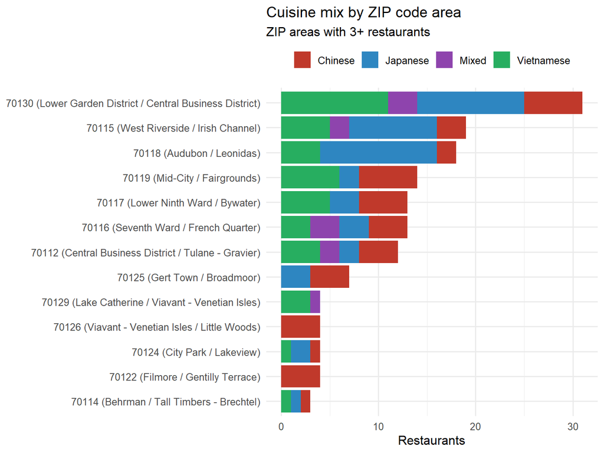

```r
mix_chart <- analysis_points |>
  st_drop_geometry() |>
  select(business_id, cuisine) |>
  inner_join(zip_assign, by = "business_id") |>
  add_count(zip_label, name = "zip_total") |>
  filter(zip_total >= min_area_restaurants) |>
  mutate(zip_label = fct_reorder(zip_label, zip_total)) |>
  ggplot(aes(y = zip_label, fill = cuisine)) +
  geom_bar() +
  scale_fill_manual(values = cuisine_colors) +
  labs(title = "Cuisine mix by ZIP code area",
       subtitle = paste0("ZIP areas with ", min_area_restaurants, "+ restaurants"),
       x = "Restaurants", y = NULL, fill = NULL) +
  theme(legend.position = "top")

save_fig(mix_chart, "cuisine_mix_by_zip.png", height = 6)
```

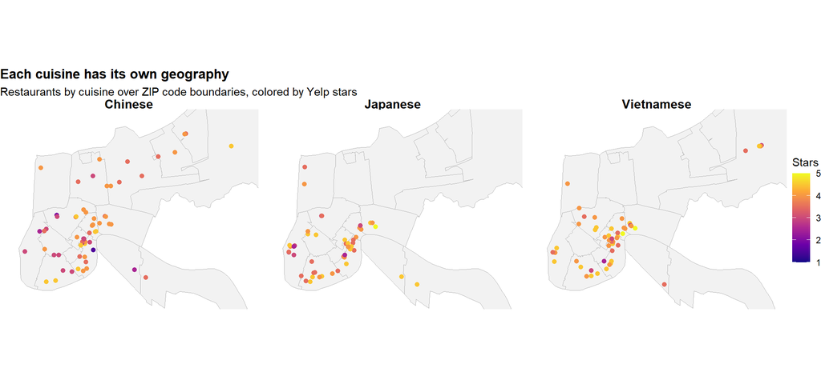

```r
cuisine_points <- analysis_points |>
  select(business_id, stars) |>
  inner_join(cuisine_long, by = "business_id")   # restaurants with two cuisines appear in both panels

zoom_bb <- st_bbox(st_buffer(st_union(analysis_points), 2500))

cuisine_maps <- ggplot() +
  geom_sf(data = zcta_areas, fill = "grey95", color = "grey70", linewidth = 0.3) +
  geom_sf(data = cuisine_points, aes(color = stars), size = 1.8) +
  scale_color_viridis_c(option = "C", limits = c(1, 5)) +
  facet_wrap(~ cuisine) +
  coord_sf(xlim = zoom_bb[c("xmin", "xmax")], ylim = zoom_bb[c("ymin", "ymax")], expand = FALSE) +
  labs(title = "Each cuisine has its own geography",
       subtitle = "Restaurants by cuisine over ZIP code boundaries, colored by Yelp stars",
       color = "Stars") +
  theme_void() +
  theme(strip.text = element_text(face = "bold", size = 12), plot.title = element_text(face = "bold"))

save_fig(cuisine_maps, "cuisine_maps.png", width = 11, height = 5)
```

```r
cuisine_zip <- cuisine_points |>
  st_drop_geometry() |>
  inner_join(zip_assign, by = "business_id") |>
  inner_join(st_drop_geometry(analysis_points) |> select(business_id, review_count), by = "business_id") |>
  group_by(cuisine, zip_label) |>
  summarise(restaurants = n(), review_weighted_stars = weighted.mean(stars, review_count), .groups = "drop")

cuisine_zip |>
  group_by(cuisine) |>
  mutate(min_needed = if (any(restaurants >= min_area_restaurants)) min_area_restaurants else 2) |>
  filter(restaurants >= min_needed) |>
  summarise(
    `ZIP areas compared` = n(),
    `Most restaurants`   = zip_label[which.max(restaurants)],
    `Highest rated`      = zip_label[which.max(review_weighted_stars)],
    `Its review-weighted stars` = round(max(review_weighted_stars), 2),
    `Minimum restaurants per area` = first(min_needed),
    .groups = "drop"
  ) |>
  rename(Cuisine = cuisine) |>
  kable(caption = "For each cuisine: where the most restaurants are vs. where the best-rated ones are")
```

For each cuisine: where the most restaurants are vs. where the best-rated ones are

| Cuisine | ZIP areas compared | Most restaurants | Highest rated | Its review-weighted stars | Minimum restaurants per area |
| --- | --- | --- | --- | --- | --- |
| Chinese | 9 | 70130 (Lower Garden District / Central Business District) | 70116 (Seventh Ward / French Quarter) | 4.19 | 3 |
| Japanese | 6 | 70118 (Audubon / Leonidas) | 70125 (Gert Town / Broadmoor) | 4.32 | 3 |
| Vietnamese | 8 | 70130 (Lower Garden District / Central Business District) | 70129 (Lake Catherine / Viavant - Venetian Isles) | 4.27 | 3 |

### Best areas overall

[figure not shown]

```r
zip_chart <- zip_table |>
  filter(comparable) |>
  mutate(zip_label = fct_reorder(zip_label, review_weighted_stars)) |>
  ggplot(aes(review_weighted_stars, zip_label)) +
  geom_segment(aes(x = 1, xend = review_weighted_stars, yend = zip_label), color = "grey80") +
  geom_point(aes(size = restaurants), color = "#C0392B") +
  geom_text(aes(label = paste0(restaurants, " restaurants")), hjust = -0.3, size = 3, color = "grey30") +
  scale_x_continuous(limits = c(1, 5.5), breaks = 1:5) +
  labs(title = "Which parts of New Orleans have the best-rated Chinese, Vietnamese, and Japanese food?",
       subtitle = paste0("ZIP areas with ", min_area_restaurants, "+ restaurants; review-weighted Yelp stars"),
       x = "Review-weighted stars", y = NULL, size = "Restaurants")

save_fig(zip_chart, "ratings_by_zip.png", height = 6)
```

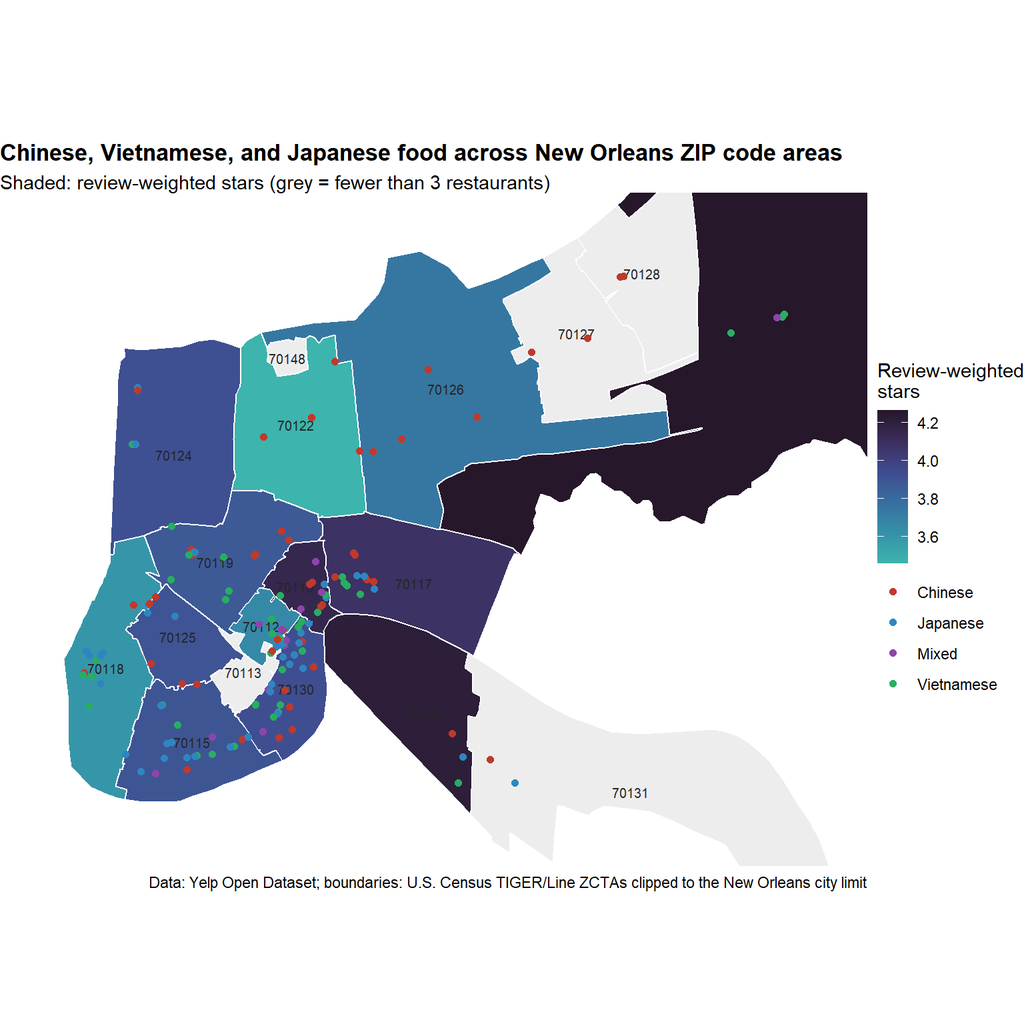

```r
final_map_data <- zcta_areas |>
  left_join(select(zip_table, area_name, review_weighted_stars, comparable), by = "area_name") |>
  mutate(map_value = if_else(comparable %in% TRUE, review_weighted_stars, NA_real_))

final_map <- ggplot() +
  geom_sf(data = final_map_data, aes(fill = map_value), color = "white", linewidth = 0.5) +
  geom_sf_text(data = final_map_data, aes(label = area_name), size = 2.6, color = "grey15") +
  geom_sf(data = analysis_points, aes(color = cuisine), size = 1.6) +
  scale_fill_viridis_c(option = "mako", direction = -1, begin = 0.1, end = 0.7, na.value = "grey93",
                       name = "Review-weighted\nstars") +
  scale_color_manual(values = cuisine_colors, name = NULL) +
  coord_sf(xlim = zoom_bb[c("xmin", "xmax")], ylim = zoom_bb[c("ymin", "ymax")], expand = FALSE) +
  labs(title = "Chinese, Vietnamese, and Japanese food across New Orleans ZIP code areas",
       subtitle = paste0("Shaded: review-weighted stars (grey = fewer than ", min_area_restaurants, " restaurants)"),
       caption = "Data: Yelp Open Dataset; boundaries: U.S. Census TIGER/Line ZCTAs clipped to the New Orleans city limit") +
  theme_void() +
  theme(plot.title = element_text(face = "bold"))

save_fig(final_map, "final_zip_map.png", width = 9, height = 8)
```

### Preliminary answer

Among ZIP areas with at least 3 restaurants, **70129 (Lake Catherine / Viavant - Venetian Isles)** has the highest review-weighted rating (4.27 stars across 4 restaurants). **70130 (Lower Garden District / Central Business District)** has the most restaurants (31). Step 7 tests whether this holds after adjusting for reviewer habits.